# Group 3 - Assignment 1

## Data, Objective, and Contribution

These maps utilize open-source data from the City of Chicago. For our points data, we chose a KML file of the stops along the CTA L train, the major public transit system in the city. For polygons, we looked at boundaries of the Illinois Enterprise Zone Program in Chicago. This program earmarks certain economically depressed areas across the state for targeted revitalization through a combination of state and local tax incentives.

Our goal was to identify any correlations in the spatial relationship between public transit and economic development through this program. Each team member created an individual map using a base map, Enterprise Zones data, and CTA L Stops. Afterwards, all team members created one collaborative map that was designated the “bad” map, using red polygons, a black base map, and pink points. Due to technical difficulties, the code for each member was added to Yirong’s and Emma’s RStudio to create the final html file.

As a group we completed: working through videos, finding data, troubleshooting GitHub as a team, coming up with our “bad map”, came together multiple times to continue work. Team members determined that the level of contribution from everyone was relatively equal, barring technical difficulties. Grading is as follows:

Emma: 10 – Found data sets for CTA-L-Stops, 1 individual map, helped with collaborative “bad” map, uploads to Github, statement for individual map, introduction for “Contribution Statement”

Gabriel: 10 – Found data sets for Enterprise Zones, 1 individual map, helped with collaborative “bad” map, statement for individual map, statement for “bad” map, set up shared documents to edit texts

Jaida: 10 - 1 individual map, helped with collaborative “bad” map, statement for individual map, grading breakdown for “Contribution Statement”, description of tasks in “Contribution Statement”

Yirong: 10 - 1 individual map, helped with collaborative “bad” map, uploads to Github, statement for individual map, created HTML file for group

## Loading packages

```r
library(sf)
library(tidyverse)
library(ggthemes)
library(ggspatial)
library(dplyr)
library(ggplot2)
```

## Loading Data

```r
Ezones <- st_read("https://data.cityofchicago.org/api/geospatial/64xf-pyvh?method=export&format=KML")
Lstops <- st_read("https://data.cityofchicago.org/download/4qtv-9w43/application%2Fxml")
```

## Map 1 - “Bad Map”

It is important for data visualizations/maps to provide data in a clear and concise manner. While the colors utilized in this map provide great contrast, it is challenging to understand what is being shown. The spacing and size of the CTA-L-Stops, color and opacity of the Enterprise Zones, and very dark color of the base map result in a visualization that is unclear. This map is “bad.”

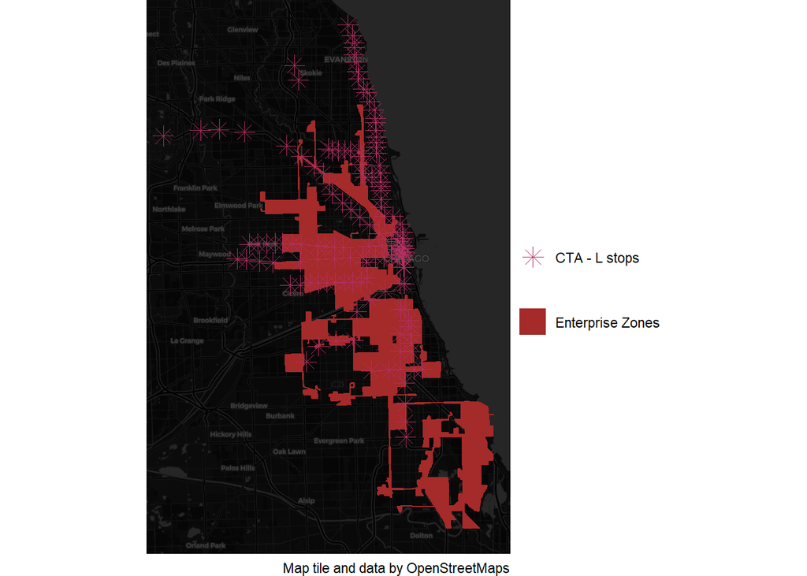

```r
ggplot() +
  annotation_map_tile(zoomin = 0, progress = "none", type = "cartodark")  +
  geom_sf() +
  labs(caption = "Map tile and data by OpenStreetMaps")+
  geom_sf(data = Ezones, color = "brown",
                        aes(fill = "Enterprise Zones")) +
  geom_sf(data = Lstops,
          size = 4,
          shape = 8,
          aes(color = "CTA - L stops")) +
  scale_fill_manual(values = "brown", name = "") +
  scale_color_manual(values = "maroon", name = "") +
  theme_void()
```

## Map 2

This Map used a black-white base map that includes details of the city’s administrative boundaries and light fill color with transparency to show its relationship with the Enterprise Zones. Then a more contrasted color is used to represent the L Stops. The resulting map fails to show the relationship between the Enterprise Zone and the L Stops, as the polygon element is not so clearly standing out from the rest of the map. The fill color needs to be adjusted to a stronger type and with a darker outline.

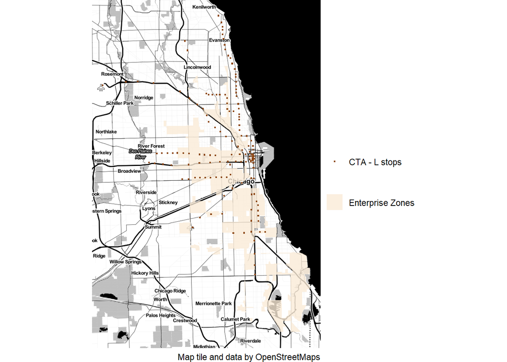

```r
ggplot()+
  annotation_map_tile(zoomin = 0, progress = "none", type = "stamenbw")  +
  geom_sf() +
  labs(caption = "Map tile and data by OpenStreetMaps")+
  geom_sf(data=Ezones, color=NA, alpha=0.8,
          aes(fill="Enterprise Zones"))+
  geom_sf(data=Lstops, shape=15, size=0.4,
          aes(color="CTA - L stops"))+
  scale_fill_manual(values = "antiquewhite",name="")+
  scale_color_manual(values=c("chocolate4"),name="")+
  theme_void()
```

## Map 3

While this map utilizes a contrasting color scheme to differentiate between the data shown, the choice of color of the base map pulls focus away from the Enterprise Zones and CTA-L-Stops. Choosing a lighter base map, outlining the Enterprise Zones and lowering the opacity, and shifting the color for both the Enterprise Zones and CTA-L-Stops would make this map more effective.

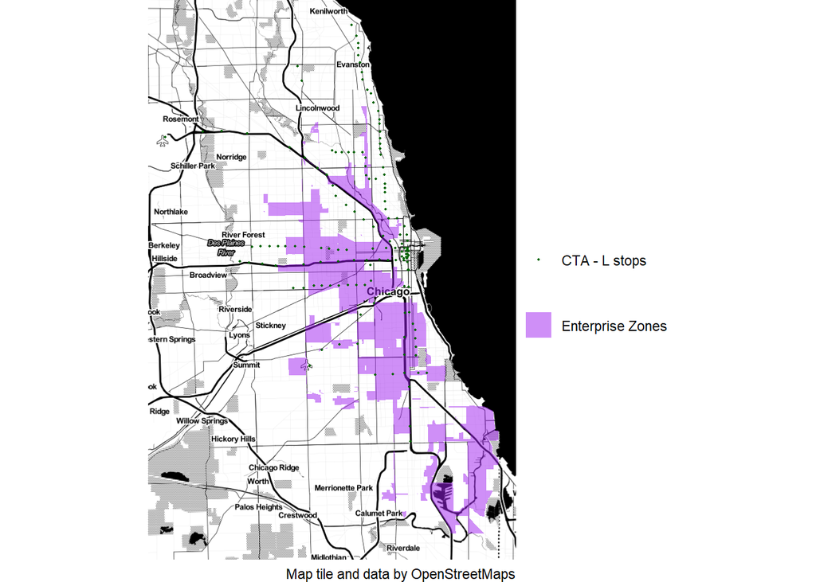

```r
ggplot() +
  annotation_map_tile(zoomin = 0, progress = "none", type = "stamenbw") +
  geom_sf() +
  labs(caption = "Map tile and data by OpenStreetMaps") +
  geom_sf(data = Ezones, color = NA, alpha = 0.5,
          aes(fill = "Enterprise Zones")) +
  geom_sf(data = Lstops, size = 0.4,
          aes(color = "CTA - L stops")) +
  scale_fill_manual(values = "purple", name = "") +
  scale_color_manual(values = "darkgreen", name = "") +
  theme_void()
```

## Map 4

This map used a neutral Chicago base map to emphasize the distinct Enterprise Zones and CTA L Stop points. Even though the points were designated as “diamond” shapes, many appear to have circular shapes, depending on the scale. Thus, it would have been better to maintain a circular shape, rather than have various shapes displayed on the map. Increasing the size would congest the map and make analysis more difficult. However, given the color and scale, the map appears to emphasize Enterprise Zones. Overall, not a bad map, but I need to further understand intentionality of my maps first!😊

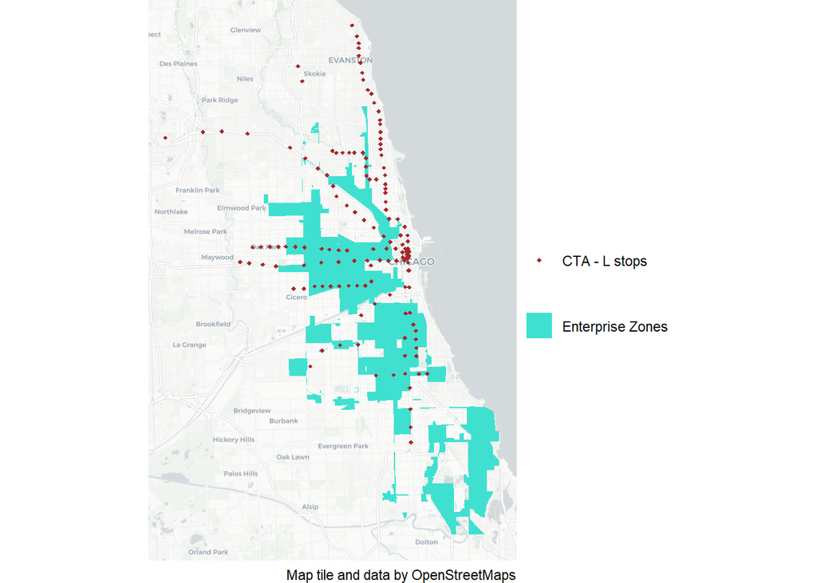

```r
ggplot() +
  annotation_map_tile(zoomin = 0, progress = "none", type = "cartolight")  +
  labs(caption = "Map tile and data by OpenStreetMaps") +
  geom_sf(data = Ezones, color = "NA", aes(fill = "Enterprise Zones")) +
  geom_sf(data = Lstops, shape = 18, size = 1, aes(color = "CTA - L stops")) +
  scale_fill_manual(values = "turquoise", name = "") +
  scale_color_manual(values = "brown", name = "")   +
  theme_void()
```

## Map 5 - Best Map

This map highlights the relationship between the Enterprise Zones and L stops primarily through color and contrast. A lighter basemap helps the spatial data stand out, as the purpose of this map is less about the roads, parcels and other geography present in the basemap and more about the correlation between the Enterprise Zones and L stops. Opacity is lowered for the Enterprise Zones in order to highlight the L-stops on the top layer, while the boundaries of the zones are still preserved through a darker outline.

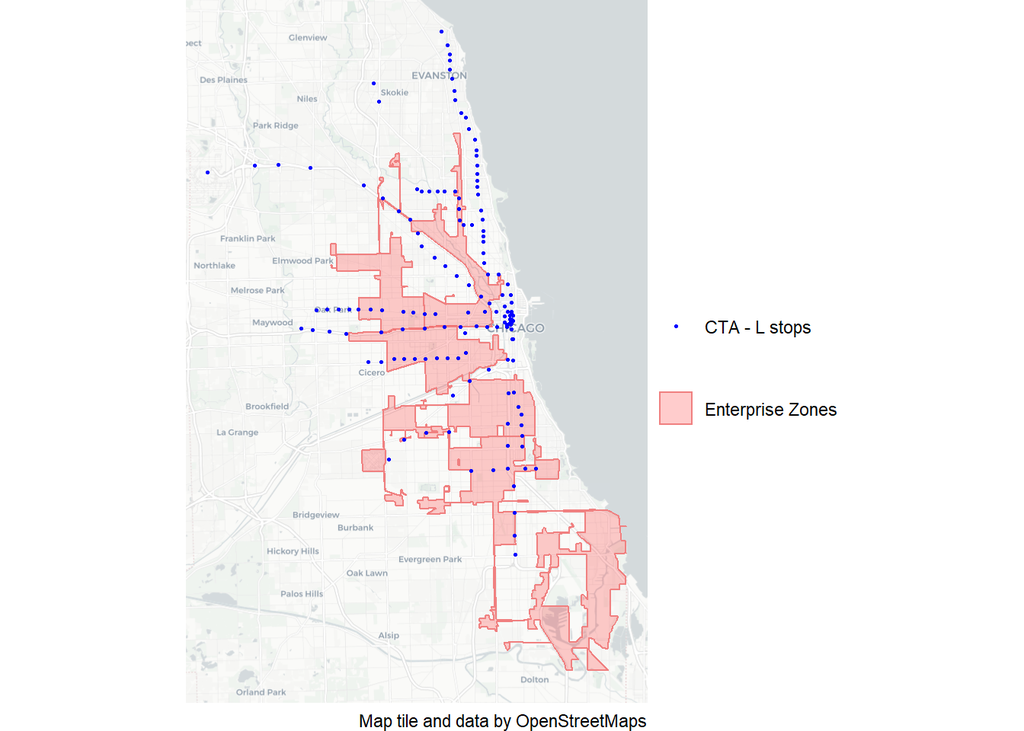

```r
ggplot() +
  annotation_map_tile(zoomin = 0, progress = "none", type = "cartolight")  +
  geom_sf() +
  labs(caption = "Map tile and data by OpenStreetMaps")+
  geom_sf(data = Ezones, color = "lightcoral",alpha = 0.2,
                        aes(fill = "Enterprise Zones")) +
  geom_sf(data = Lstops,
          size = 0.5,
          aes(color = "CTA - L stops")) +
  scale_fill_manual(values = "red", name = "") +
  scale_color_manual(values = "blue", name = "") +
  theme_void()
```